# Stock-specific von Bertalanffy growth parameters from survey length-at-age data

Author

Max Lindmark

Published

2026-08-27

## Background

The VBGE parameters ($L_\infty$, $K$) used in `04-glmm-hgam.qmd` come from FishLife (`icesdata`’s `fishlife` attribute), which is resolved at the *species* level, not the *stock* level – every stock of e.g. `Gadus morhua` gets the same $L_\infty$/$K$ regardless of which stock it actually is.

Here we instead fit a standard VBGE per *stock*, using survey length-at-age data from `wggrafy-data` project (`north-east-atlantic-datras` region), restricted to the ICES subdivisions each stock occupies.

## Load libraries

```r
library(dplyr)
library(tidyr)
library(readr)
library(purrr)
library(tibble)
library(ggplot2)
library(RTMB)
library(raster)
library(sp)
library(icesdata)
library(ggsidekick)
library(tictoc)

theme_set(theme_sleek())

home <- here::here()

# wggrafy-data is a sibling project (not part of this repo)
wggrafy_home <- paste0(dirname(home), "/wggrafy-data")
```

## Stocks going into script 04, and their current (species-level) VBGE parameters

```r
dat <- read_csv(paste0(home, "/output/dat.csv"), show_col_types = FALSE)

stock_species <- dat |> distinct(stock, species = Species)
stocks <- stock_species$stock

n_distinct(stocks)
```

```
[1] 79
```

```r
# Current approach (as in 04-glmm-hgam.qmd): FishLife linf/k, resolved per stock name
# in icesdata but only varying by species (duplicated across stocks of the same species)
current_vbge <- names(icesdata) |>
  map(function(stock_name) {
    stk <- icesdata[[stock_name]]
    fl <- attributes(stk)$fishlife
    if (is.null(fl)) {
      return(NULL)
    }
    tibble(stock = stock_name, linf_current = unname(fl["linf"]), k_current = unname(fl["k"]))
  }) |>
  list_rbind() |>
  filter(stock %in% stocks)

current_vbge
```

```
# A tibble: 79 × 3
   stock            linf_current k_current
   <chr>                   <dbl>     <dbl>
 1 ank.27.78abd             88.1     0.111
 2 aru.27.5a14              44.2     0.198
 3 aru.27.5b6a              44.2     0.198
 4 bss.27.4bc7ad-h          75.1     0.172
 5 bss.27.8ab               75.1     0.172
 6 cod.21.1                104.      0.165
 7 cod.2127.1f14           104.      0.165
 8 cod.27.1-2              104.      0.165
 9 cod.27.1-2coastN        104.      0.165
10 cod.27.22-24            104.      0.165
# ℹ 69 more rows
```

## Map each stock to its ICES subdivisions

Same key + manual patches as `03-join-env-flr.R`.

```r
key <- read_csv(paste0(home, "/data/stocks_per_area2025.csv"), show_col_types = FALSE) |>
  mutate(sub_div = sub("^27\\.", "", ICES_Area)) |>
  mutate(
    StockKeyLabel = ifelse(StockKeyLabel == "cod.21.1.isc", "cod.21.1", StockKeyLabel),
    StockKeyLabel = ifelse(StockKeyLabel == "cod.27.1-2.coastN", "cod.27.1-2coastN", StockKeyLabel)
  ) |>
  mutate(sub_div = ifelse(StockKeyLabel %in% c("cod.21.1", "cod.27.1-2coastN"), "1.b", sub_div)) |>
  filter(StockKeyLabel %in% stocks)

stopifnot(all(stocks %in% key$StockKeyLabel))
```

## Read survey length-at-age data and assign ICES subdivisions

```r
tic()
len <- readRDS(paste0(wggrafy_home, "/outputs/length_all.rds")) |>
  filter(!is.na(lngt_cm), !is.na(age), !is.na(lon), !is.na(lat))
toc()
```

```
8.207 sec elapsed
```

```r
# sp/over on unique coordinates only (much faster than per-row), same approach as
# the ICES sub-division join in 01-sal-sst.R
shape <- shapefile(paste0(home, "/data/shapefiles/StatRec_map_Areas_Full_20170124.shp"))

uniq_coords <- len |> distinct(lon, lat)
pts <- SpatialPoints(cbind(uniq_coords$lon, uniq_coords$lat), proj4string = CRS(proj4string(shape)))
uniq_coords$sub_div <- over(pts, shape)$Area_27

len <- len |>
  left_join(uniq_coords, by = c("lon", "lat")) |>
  filter(!is.na(sub_div))
```

## Filter length-at-age data per stock, track coverage, bind rows

For each stock: filter survey data to its species and its ICES subdivisions (from `key`), then record how many of the stock’s subdivisions actually have survey data, and how the survey year range compares to the year range of the `b0` data used in script 04.

```r
b0 <- readRDS(paste0(home, "/output/b0.rds"))
b0_yr <- b0 |>
  summarise(b0_yr_min = min(year), b0_yr_max = max(year), .by = sid)

coverage_list <- vector("list", length(stocks))
laa_list <- vector("list", length(stocks))

for (i in seq_along(stocks)) {
  s <- stocks[i]
  sp_name <- stock_species$species[stock_species$stock == s]
  key_sub <- key |> filter(StockKeyLabel == s)

  laa <- len |> filter(species == sp_name, sub_div %in% key_sub$sub_div)

  b0r <- b0_yr |> filter(sid == s)

  coverage_list[[i]] <- tibble(
    stock = s,
    species = sp_name,
    n_subdiv_total = n_distinct(key_sub$sub_div),
    n_subdiv_with_data = n_distinct(laa$sub_div),
    n_rows = nrow(laa),
    n_ages = n_distinct(laa$age),
    laa_yr_min = suppressWarnings(min(laa$year)),
    laa_yr_max = suppressWarnings(max(laa$year)),
    b0_yr_min = b0r$b0_yr_min,
    b0_yr_max = b0r$b0_yr_max
  )

  if (nrow(laa) > 0) laa_list[[i]] <- laa |> mutate(stock = s)
}

coverage <- bind_rows(coverage_list) |>
  mutate(
    # descriptive only, survey data is NOT filtered to the b0 year range
    laa_covers_b0_range = laa_yr_min <= b0_yr_min & laa_yr_max >= b0_yr_max
  )

laa_all <- bind_rows(laa_list)

write_csv(coverage, paste0(home, "/output/vbge_stock_coverage.csv"))

coverage |> arrange(n_rows) |> print(n = 100)
```

```
# A tibble: 79 × 11
   stock      species n_subdiv_total n_subdiv_with_data n_rows n_ages laa_yr_min
   <chr>      <chr>            <int>              <int>  <int>  <int>      <dbl>
 1 aru.27.5a… Argent…              5                  0      0      0        Inf
 2 aru.27.5b… Argent…              2                  0      0      0        Inf
 3 cod.21.1   Gadus …              1                  0      0      0        Inf
 4 cod.2127.… Gadus …              5                  0      0      0        Inf
 5 cod.27.1-2 Gadus …              8                  0      0      0        Inf
 6 cod.27.1-… Gadus …              1                  0      0      0        Inf
 7 cod.27.5a  Gadus …              2                  0      0      0        Inf
 8 cod.27.5b1 Gadus …              2                  0      0      0        Inf
 9 had.27.1-2 Melano…              6                  0      0      0        Inf
10 had.27.5a  Melano…              2                  0      0      0        Inf
11 had.27.5b  Melano…              3                  0      0      0        Inf
12 her.27.30… Clupea…              2                  0      0      0        Inf
```

[output cut: 69 more lines]

```r
cat(
  "Stocks with zero survey rows:", sum(coverage$n_rows == 0), "of", nrow(coverage), "\n",
  "Stocks with data in every one of their subdivisions:",
  sum(coverage$n_subdiv_with_data == coverage$n_subdiv_total), "\n"
)
```

```
Stocks with zero survey rows: 23 of 79
 Stocks with data in every one of their subdivisions: 32
```

## Coverage plots

Two overlapping, semi-transparent bars per stock: a background bar (grey) for the full extent the stock is defined over, and a foreground bar (blue) for what’s actually covered by survey data. Where they match exactly, the blue bar fully covers the grey one and it reads as a single solid bar; any grey showing past the blue is the shortfall.

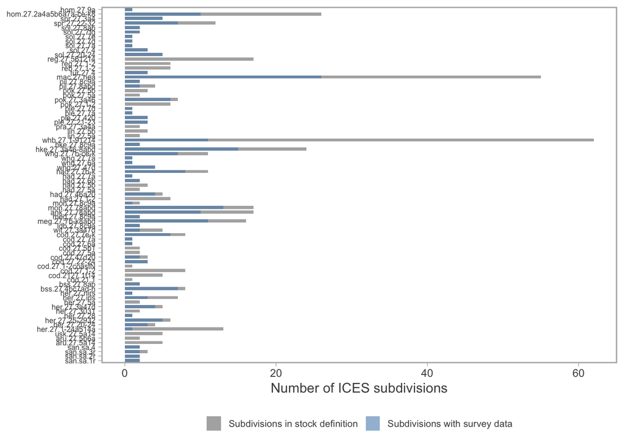

```r
stock_order <- stock_species |> arrange(species, stock) |> pull(stock)

subdiv_cov_dat <- coverage |>
  transmute(stock, `Subdivisions in stock definition` = n_subdiv_total, `Subdivisions with survey data` = n_subdiv_with_data) |>
  pivot_longer(-stock, names_to = "type", values_to = "n") |>
  mutate(stock = factor(stock, levels = stock_order))

ggplot(subdiv_cov_dat, aes(y = stock, x = n, fill = type)) +
  geom_col(position = "identity", alpha = 0.55, width = 0.7) +
  scale_fill_manual(values = c(
    "Subdivisions in stock definition" = "grey40",
    "Subdivisions with survey data"    = "steelblue"
  )) +
  labs(x = "Number of ICES subdivisions", y = NULL, fill = NULL) +
  theme(legend.position = "bottom", axis.text.y = element_text(size = 6))
```

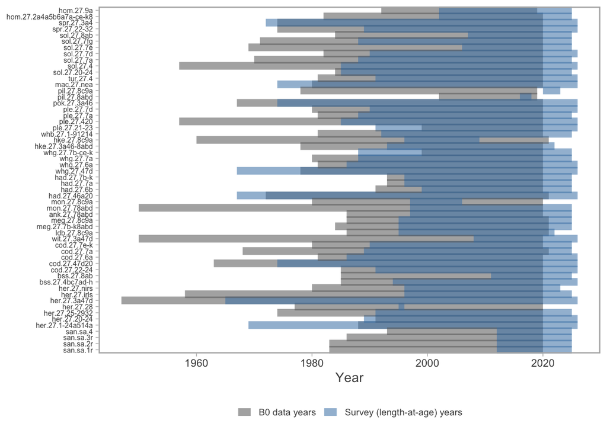

```r
ggsave(paste0(home, "/figures/supp/vbge_coverage_subdivisions.pdf"), width = 14, height = 26, units = "cm")

year_cov_dat <- coverage |>
  filter(n_rows > 0) |> # laa_yr_min/max are +-Inf when a stock has zero survey rows
  transmute(stock, species, b0_yr_min, b0_yr_max, laa_yr_min, laa_yr_max) |>
  pivot_longer(-c(stock, species), names_to = c("type", ".value"), names_pattern = "(.*)_yr_(min|max)") |>
  mutate(
    type = recode(type, b0 = "B0 data years", laa = "Survey (length-at-age) years"),
    stock = factor(stock, levels = stock_order)
  )

ggplot(year_cov_dat, aes(y = stock, color = type)) +
  geom_segment(aes(x = min, xend = max, yend = stock), linewidth = 3, alpha = 0.55) +
  scale_color_manual(values = c(
    "B0 data years"                 = "grey40",
    "Survey (length-at-age) years"  = "steelblue"
  )) +
  labs(x = "Year", y = NULL, color = NULL) +
  theme(legend.position = "bottom", axis.text.y = element_text(size = 6))
```

```r
ggsave(paste0(home, "/figures/supp/vbge_coverage_years.pdf"), width = 14, height = 26, units = "cm")
```

## Fit stock-specific VBGE with RTMB

Standard (non-omega, non-spatial, non-time-varying) VBGE:

$$\hat{l}_i = L_\infty \left(1 - e^{-K(a_i - t_0)}\right), \quad \log(l_i) \sim \text{Normal}(\log(\hat{l}_i), \sigma^2)$$

fit independently per stock. Stocks with too little data to identify three growth parameters are skipped.

```r
min_n_rows <- 30
min_n_ages <- 3

fit_vbge <- function(age, length) {
  tmb_data <- list(age = age, length = length)

  par <- list(
    log_Linf  = log(max(length) * 1.1),
    log_K     = log(0.2),
    # t0 starts < 0 so pred > 0 at age 0 (pred = 0 at age = t0, which gives -Inf
    # log-likelihood and breaks the optimizer if t0 starts at/above the min observed age)
    t0        = -0.5,
    log_sigma = log(0.2)
  )

  lower <- c(log_Linf = log(max(length) * 0.5), log_K = log(0.01), t0 = -10, log_sigma = log(0.01))
  upper <- c(log_Linf = log(max(length) * 3),   log_K = log(2),    t0 = 5,   log_sigma = log(5))

  nll <- function(par) {
    getAll(par, tmb_data)

    Linf  <- exp(log_Linf)
    K     <- exp(log_K)
    sigma <- exp(log_sigma)

    pred <- Linf * (1 - exp(-K * (age - t0)))

    log(length) %~% dnorm(log(pred), sigma)

    ADREPORT(Linf)
    ADREPORT(K)
  }

  obj <- MakeADFun(nll, par, silent = TRUE)
  opt <- tryCatch(nlminb(obj$par, obj$fn, obj$gr, lower = lower, upper = upper), error = function(e) NULL)
  if (is.null(opt) || opt$convergence != 0) {
    return(list(status = "opt_fail", estimates = NULL))
  }

  tol <- 0.02 * (upper - lower)
  at_bound <- (upper["log_Linf"] - opt$par["log_Linf"]) < tol["log_Linf"] ||
    (opt$par["log_K"] - lower["log_K"]) < tol["log_K"]
  if (at_bound) {
    return(list(status = "boundary", estimates = NULL))
  }

  sdr <- tryCatch(sdreport(obj), error = function(e) NULL)
  if (is.null(sdr) || !sdr$pdHess) {
    return(list(status = "no_hess", estimates = NULL))
  }

  s <- summary(sdr, "report")
  list(
    status = "ok",
    estimates = tibble(
      parameter = rownames(s),
      estimate  = s[, "Estimate"],
      se        = s[, "Std. Error"]
    )
  )
}

fit_stocks <- coverage |>
  filter(n_rows >= min_n_rows, n_ages >= min_n_ages) |>
  pull(stock)

length(fit_stocks)
```

```
[1] 56
```

```r
tic()
vbge_fits_list <- vector("list", length(fit_stocks))
fit_status_list <- vector("list", length(fit_stocks))

for (i in seq_along(fit_stocks)) {
  s <- fit_stocks[i]
  sub <- laa_all |> filter(stock == s)

  fit <- fit_vbge(age = sub$age, length = sub$lngt_cm)

  fit_status_list[[i]] <- tibble(stock = s, fit_status = fit$status)

  if (!is.null(fit$estimates)) {
    vbge_fits_list[[i]] <- fit$estimates |> mutate(stock = s)
  }
}
toc()
```

```
19.619 sec elapsed
```

```r
vbge_fits <- bind_rows(vbge_fits_list)
fit_status <- bind_rows(fit_status_list)

fit_status |> count(fit_status)
```

```
# A tibble: 2 × 2
  fit_status     n
  <chr>      <int>
1 boundary       6
2 ok            50
```

## Plausibility check: drop implausible Linf estimates

The bound check above only catches fits that ran all the way to the box constraint. A generous bound (3x the stock’s own max observed length) leaves room for some fits to settle on the same Linf -> Inf, K -> 0 identifiability ridge at a point that’s *locally* well-conditioned (converges, passes pdHess) but still biologically implausible – e.g. `cod.27.6a` at Linf = 209 cm, `pok.27.3a46` at 197 cm.

FishLife’s species-level Linf is an independent, literature-based sanity check. Comparing `Linf_new / Linf_species` across all “ok” fits shows most stocks sit close to their species value (IQR 0.83-1.16), then a clean gap, then a small cluster from 1.55 up to 2.33 – those are the same identifiability-ridge fits (paired with an implausibly small K), so anything above that gap is dropped back to the species-level fallback.

```r
plausibility_ratio_max <- 1.5

linf_ratio_check <- vbge_fits |>
  filter(parameter == "Linf") |>
  transmute(stock, linf_new = estimate) |>
  left_join(current_vbge, by = "stock") |>
  mutate(linf_ratio = linf_new / linf_current) |>
  arrange(desc(linf_ratio))

linf_ratio_check |> print(n = 60)
```

```
# A tibble: 50 × 5
   stock                   linf_new linf_current k_current linf_ratio
   <chr>                      <dbl>        <dbl>     <dbl>      <dbl>
 1 whg.27.7a                  104.          44.7     0.290      2.33
 2 cod.27.6a                  209.         104.      0.165      2.00
 3 had.27.7a                  130.          66.6     0.241      1.95
 4 pok.27.3a46                197.         115.      0.129      1.71
 5 bss.27.4bc7ad-h            120.          75.1     0.172      1.60
 6 cod.27.7e-k                166.         104.      0.165      1.58
 7 ank.27.78abd               138.          88.1     0.111      1.56
 8 whg.27.6a                   69.1         44.7     0.290      1.55
 9 spr.27.3a4                  21.0         15.1     0.521      1.39
10 hke.27.3a46-8abd            98.6         80.2     0.141      1.23
11 her.27.nirs                 37.1         30.4     0.337      1.22
12 her.27.3a47d                36.0         30.4     0.337      1.19
```

[output cut: 38 more lines]

```r
implausible_stocks <- linf_ratio_check |>
  filter(linf_ratio > plausibility_ratio_max) |>
  pull(stock)

cat(
  "Dropped as implausible (Linf >", plausibility_ratio_max, "x species-level Linf):\n ",
  paste(implausible_stocks, collapse = ", "), "\n"
)
```

```
Dropped as implausible (Linf > 1.5 x species-level Linf):
  whg.27.7a, cod.27.6a, had.27.7a, pok.27.3a46, bss.27.4bc7ad-h, cod.27.7e-k, ank.27.78abd, whg.27.6a
```

```r
vbge_fits <- vbge_fits |> filter(!(stock %in% implausible_stocks))
fit_status <- fit_status |>
  mutate(fit_status = ifelse(stock %in% implausible_stocks, "implausible_linf", fit_status))

saveRDS(vbge_fits, paste0(home, "/output/vbge_stock_fits.rds"))
write_csv(fit_status, paste0(home, "/output/vbge_stock_fit_status.csv"))

fit_status |> count(fit_status)
```

```
# A tibble: 3 × 2
  fit_status           n
  <chr>            <int>
1 boundary             6
2 implausible_linf     8
3 ok                  42
```

```r
cat(
  "Usable stock-specific VBGE fits:", sum(fit_status$fit_status == "ok"),
  "of", length(fit_stocks), "attempted stocks\n",
  "(the rest either hit the identifiability ridge -- long-lived species sampled almost",
  "entirely as juveniles -- or were dropped by the plausibility check above; both fall",
  "back to the species-level value in the final dataset below)\n"
)
```

```
Usable stock-specific VBGE fits: 42 of 56 attempted stocks
 (the rest either hit the identifiability ridge -- long-lived species sampled almost entirely as juveniles -- or were dropped by the plausibility check above; both fall back to the species-level value in the final dataset below)
```

## Caterpillar plot: current (species-level) vs. stock-specific VBGE parameters

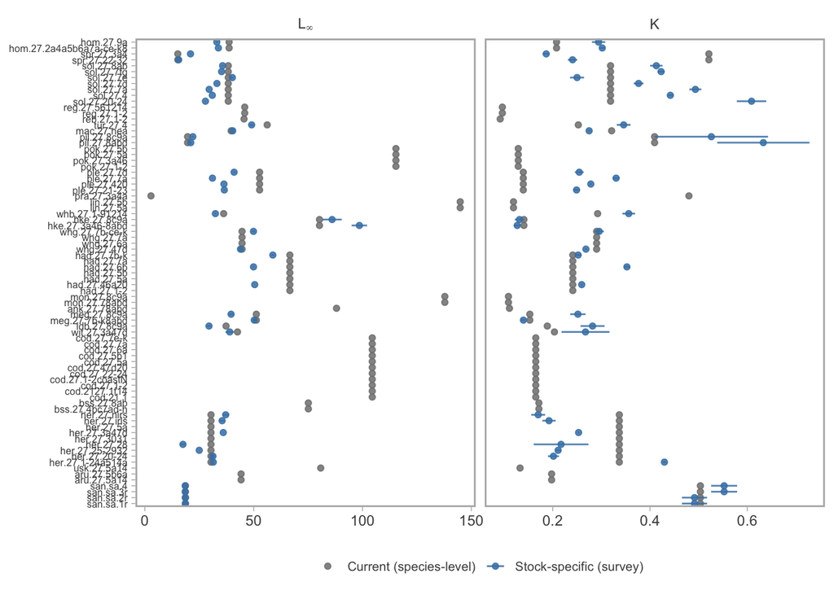

```r
new_vbge <- vbge_fits |>
  mutate(
    conf.low  = estimate - 1.96 * se,
    conf.high = estimate + 1.96 * se
  ) |>
  dplyr::select(stock, parameter, estimate, conf.low, conf.high) |>
  mutate(source = "Stock-specific (survey)")

current_long <- current_vbge |>
  pivot_longer(c(linf_current, k_current), names_to = "parameter", values_to = "estimate") |>
  mutate(
    parameter = ifelse(parameter == "linf_current", "Linf", "K"),
    conf.low = NA_real_,
    conf.high = NA_real_,
    source = "Current (species-level)"
  )

cater_dat <- bind_rows(current_long, new_vbge) |>
  left_join(stock_species, by = "stock") |>
  mutate(
    parameter = factor(parameter, levels = c("Linf", "K"), labels = c("L[infinity]", "K")),
    stock = factor(stock, levels = stock_species |> arrange(species, stock) |> pull(stock))
  )

n_stocks_plot <- n_distinct(cater_dat$stock)

ggplot(cater_dat, aes(y = stock, x = estimate, color = source)) +
  geom_point(size = 1.4, alpha = 0.85) +
  geom_errorbarh(
    data = cater_dat |> filter(source == "Stock-specific (survey)"),
    aes(xmin = conf.low, xmax = conf.high),
    height = 0, alpha = 0.85
  ) +
  facet_wrap(~parameter, scales = "free_x", labeller = label_parsed) +
  scale_color_manual(values = c(
    "Current (species-level)" = "grey50",
    "Stock-specific (survey)" = "steelblue"
  )) +
  labs(x = NULL, y = NULL, color = NULL) +
  theme(
    legend.position = "bottom",
    axis.text.y = element_text(size = 6)
  )
```

```r
# ggsave(paste0(home, "/figures/vbge_stock_vs_species_caterpillar.pdf"),
#   width = 18, height = 26, units = "cm"
# )
```

## Final VBGE parameter set for script 04

One row per stock: the stock-specific (survey) estimate where the fit was identifiable (`fit_status == "ok"`), falling back to the current species-level FishLife value otherwise.

```r
new_wide <- vbge_fits |>
  dplyr::select(stock, parameter, estimate) |>
  pivot_wider(names_from = parameter, values_from = estimate) |>
  rename(linf_new = Linf, k_new = K)

vbge_final <- stock_species |>
  left_join(current_vbge, by = "stock") |>
  left_join(new_wide, by = "stock") |>
  mutate(
    source = ifelse(!is.na(linf_new) & !is.na(k_new), "stock-specific (survey)", "current (species-level)"),
    Linf = ifelse(!is.na(linf_new), linf_new, linf_current),
    K = ifelse(!is.na(k_new), k_new, k_current)
  ) |>
  dplyr::select(stock, species, Linf, K, source)

stopifnot(all(!is.na(vbge_final$Linf)), all(!is.na(vbge_final$K)))

vbge_final |> count(source)
```

```
# A tibble: 2 × 2
  source                      n
  <chr>                   <int>
1 current (species-level)    37
2 stock-specific (survey)    42
```

```r
write_csv(vbge_final, paste0(home, "/output/vbge_final.csv"))
saveRDS(vbge_final, paste0(home, "/output/vbge_final.rds"))

vbge_final
```

```
# A tibble: 79 × 5
   stock            species               Linf     K source
   <chr>            <chr>                <dbl> <dbl> <chr>
 1 ank.27.78abd     Lophius budegassa     88.1 0.111 current (species-level)
 2 aru.27.5a14      Argentina silus       44.2 0.198 current (species-level)
 3 aru.27.5b6a      Argentina silus       44.2 0.198 current (species-level)
 4 bss.27.4bc7ad-h  Dicentrarchus labrax  75.1 0.172 current (species-level)
 5 bss.27.8ab       Dicentrarchus labrax  75.1 0.172 current (species-level)
 6 cod.21.1         Gadus morhua         104.  0.165 current (species-level)
 7 cod.2127.1f14    Gadus morhua         104.  0.165 current (species-level)
 8 cod.27.1-2       Gadus morhua         104.  0.165 current (species-level)
 9 cod.27.1-2coastN Gadus morhua         104.  0.165 current (species-level)
10 cod.27.22-24     Gadus morhua         104.  0.165 current (species-level)
# ℹ 69 more rows
```